# PracticaStudents

Pablo Aibar

26 March 2016

### Lectura y Preparación de los datos

Descargamos el dataset de la web, y lo descomprimimos en la carpeta de datos

```r
# fileURL <- "https://archive.ics.uci.edu/ml/machine-learning-databases/00320/student.zip"
# download.file(fileURL, destfile="./DataSets/datos.zip", method="curl")
# unzip("./DataSets/datos.zip", exdir="./DataSets/")
# remove(fileURL)
```

Leemos los datasets separando los datos por “;” y creamos una lista de dataframes con los alumnos de cada asignatura

```r
students_raw <- list()
students_raw[["mat"]] <- read.table("./DataSets/student-mat.csv", row.names = NULL, sep = ";", header=TRUE)
students_raw[["por"]] <- read.table("./DataSets/student-por.csv", row.names = NULL, sep = ";", header=TRUE)
```

Observamos los DataFrames para comprobar que los datos se hayan insertado correctamente

```r
View(students_raw["mat"])
View(students_raw["por"])
```

### Transformación de los datos

Los alumnos no tienen un ID que nos permita relacionarlos, y en las instrucciones del dataset nos indican que hay 382 alumnos cursando ambas asignaturas. Por lo que para identificar los alumnos comunes a ambas matarieas utilizaremos las siguientes columnas:

```r
commonColumns <- c("school","sex","age","address","famsize","Pstatus","Medu","Fedu","Mjob","Fjob","reason","nursery","internet")
sapply(students_raw, function(x)
  {
    c(nrow(x), nrow(unique(x[,commonColumns])))
  })
```

```
##      mat por
## [1,] 395 649
## [2,] 391 637
```

Para estructurar los datos, creamos un único dataset fusionando los 382 alumnos duplicados con las columnas comunes

```r
allStudents <- rbind(students_raw$mat[,commonColumns], students_raw$por[, commonColumns])
allStudents <- unique(allStudents)
```

Para comprobar que la fusión de ambos datasets se hizo correctamente y que no perdimos ningún registro, comprobamos que la suma de las dimensiones de los dos datasets originales (mat y por) menos los 382 alumnos repetidos, sean iguales a la dimensión del nuevo dataframe

```r
dim(students_raw[["mat"]])[1]+dim(students_raw[["por"]])[1]-382
```

```
## [1] 662
```

```r
dim(allStudents)[1]
```

```
## [1] 662
```

Ahora que ya tenemos los registros fusionados creamos una secuencia numérica que utilizaremos como ID.

```r
allStudents <- cbind(id=1001:(1000+nrow(allStudents)), allStudents)
head(allStudents)
```

```
##     id school sex age address famsize Pstatus Medu Fedu     Mjob     Fjob
## 1 1001     GP   F  18       U     GT3       A    4    4  at_home  teacher
## 2 1002     GP   F  17       U     GT3       T    1    1  at_home    other
## 3 1003     GP   F  15       U     LE3       T    1    1  at_home    other
## 4 1004     GP   F  15       U     GT3       T    4    2   health services
## 5 1005     GP   F  16       U     GT3       T    3    3    other    other
## 6 1006     GP   M  16       U     LE3       T    4    3 services    other
##       reason nursery internet
## 1     course     yes       no
## 2     course      no      yes
## 3      other     yes      yes
## 4       home     yes      yes
## 5       home     yes       no
## 6 reputation     yes      yes
```

Como en el dataframe “allStudents” guardamos únicamente las columnas identificativas del alumno, necesitamos ahora vincularlas con los dataframes de las asignaturas

```r
studentScores <- lapply(students_raw, function(x)
  {
    tmp <- merge(allStudents, x, by=commonColumns)
    tmp[,which(!colnames(tmp) %in% commonColumns)]
  })
sapply(studentScores, dim)
```

```
##      mat por
## [1,] 395 649
## [2,]  21  21
```

Ahora ya tenemos un dataframe con los datos personales del alumno y otros con los datos académicos

```r
head(allStudents)
```

```
##     id school sex age address famsize Pstatus Medu Fedu     Mjob     Fjob
## 1 1001     GP   F  18       U     GT3       A    4    4  at_home  teacher
## 2 1002     GP   F  17       U     GT3       T    1    1  at_home    other
## 3 1003     GP   F  15       U     LE3       T    1    1  at_home    other
## 4 1004     GP   F  15       U     GT3       T    4    2   health services
## 5 1005     GP   F  16       U     GT3       T    3    3    other    other
## 6 1006     GP   M  16       U     LE3       T    4    3 services    other
##       reason nursery internet
## 1     course     yes       no
## 2     course      no      yes
## 3      other     yes      yes
## 4       home     yes      yes
## 5       home     yes       no
## 6 reputation     yes      yes
```

```r
head(studentScores$mat)
```

```
##     id guardian traveltime studytime failures schoolsup famsup paid
## 1 1096   mother          2         4        1       yes    yes  yes
## 2 1073   mother          1         2        2       yes    yes   no
## 3 1040   mother          1         1        0       yes    yes  yes
## 4 1025   mother          1         3        0       yes    yes  yes
## 5 1151    other          2         3        2        no    yes  yes
## 6 1039   mother          1         3        0       yes    yes  yes
##   activities higher romantic famrel freetime goout Dalc Walc health
## 1        yes    yes       no      3        1     2    1    1      1
## 2         no    yes      yes      3        3     4    2    4      5
## 3        yes    yes       no      4        3     1    1    1      2
## 4        yes    yes       no      4        3     2    1    1      5
## 5        yes    yes      yes      4        2     1    2    3      3
## 6        yes    yes       no      4        3     2    1    1      5
##   absences G1 G2 G3
## 1        2  7 10 10
## 2        2  8  6  5
## 3        8 14 13 13
## 4        2 10  9  8
## 5        8 10 10 10
## 6        2 12 12 11
```

### Análisis exploratorio

Calculamos la media de la nota final (G3) agrupado por horas de estudio para ver si podemos observar algún tipo de relación

```r
aggregate(studentScores$mat["G3"], studentScores$mat["studytime"], mean)
```

```
##   studytime       G3
## 1         1 10.04762
## 2         2 10.17172
## 3         3 11.40000
## 4         4 11.25926
```

```r
aggregate(studentScores$por["G3"], studentScores$por["studytime"], mean)
```

```
##   studytime       G3
## 1         1 10.84434
## 2         2 12.09180
## 3         3 13.22680
## 4         4 13.05714
```

Mostramos en un gráfico las horas de estudio y el tiempo libre para ver si hay correlación entre ambas variables

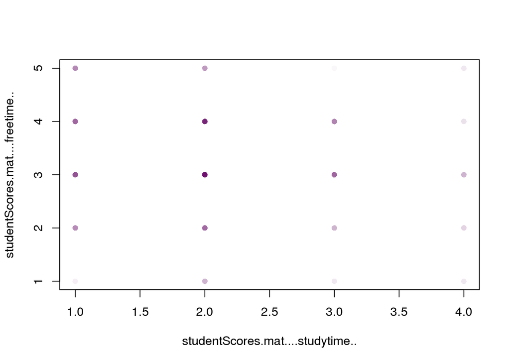

```r
plot(data.frame(studentScores$mat[,"studytime"], studentScores$mat[,"freetime"]), col="#60006008", pch=16)
```

### Modelado

Aplicamos un RandomForest para identificar las variables mas relevantes respecto a G3

```r
library(randomForest)
incCols <- unique(c(colnames(allStudents), colnames(head(studentScores$mat)[,2:18])))[-1]
thisMat <- merge(allStudents, studentScores$mat, by="id")
thisMat <- lapply(split(thisMat, thisMat$id), function(x)
{
  x[which.max(x$G3),]
})
thisMat <- do.call(rbind, thisMat)
rownames(thisMat) <- thisMat$id
rf1 <- randomForest(x=thisMat[,incCols], y=thisMat$G3, importance=TRUE, ntree=1000, proximity=TRUE)
imp <- importance(rf1)
imp <- imp[order(imp[,1], decreasing=T),]
imp
```

```
##                %IncMSE IncNodePurity
## failures   34.32038310     808.37064
## absences   32.92921966     962.07855
## schoolsup  15.90896000     169.45152
## Medu       12.40453793     332.53172
## sex        10.03409055     175.59332
## guardian    7.66646074     199.93329
## goout       6.66847907     393.97398
## Mjob        5.52942562     462.31502
## Fedu        5.47947935     233.74429
## higher      5.36594444      67.22284
## school      5.35052159      74.63040
## Pstatus     5.26835045      71.06303
## age         4.85156114     320.70957
## reason      4.07302550     310.11582
## Walc        3.40073923     228.11815
## freetime    2.78428893     272.14710
## Fjob        2.62243462     339.49756
## address     2.48913944      83.39858
## romantic    2.34483610     128.20468
## nursery     2.13011938      84.90517
## studytime   2.08869857     255.37472
## health      1.93360099     306.01431
## paid        1.82038050     111.67011
## famsup      1.47018439      99.00472
## internet    0.93220570      69.62786
## traveltime  0.52441761     192.71702
## famsize     0.51372529      89.66267
## activities  0.13435480     111.41825
## Dalc       -0.07015787     111.80866
## famrel     -0.22082874     222.60635
```

### Evaluación del modelo

En el modelado del randomForest llegamos a la conclusión de que el número de veces que se repite curso y las ausencias son las variables con mayor influencia sobre la nota final (G3). Y que las actividades extraescolares y el tamaño familiar apenas afectan.

Para comprobar la fiabilidad del modelo, hemos comparado la media de la nota final respecto a las ausencias (Una de las notas mas relevantes segun el RandomForest). Sin embargo, como podemos observar en el gráfico, no se aprecia ningún tipo de relación entre las ausencias y la nota final. Hay alumnos que faltando menos de 5 veces obtienen notas similares a alumnos con más de 40 faltas.

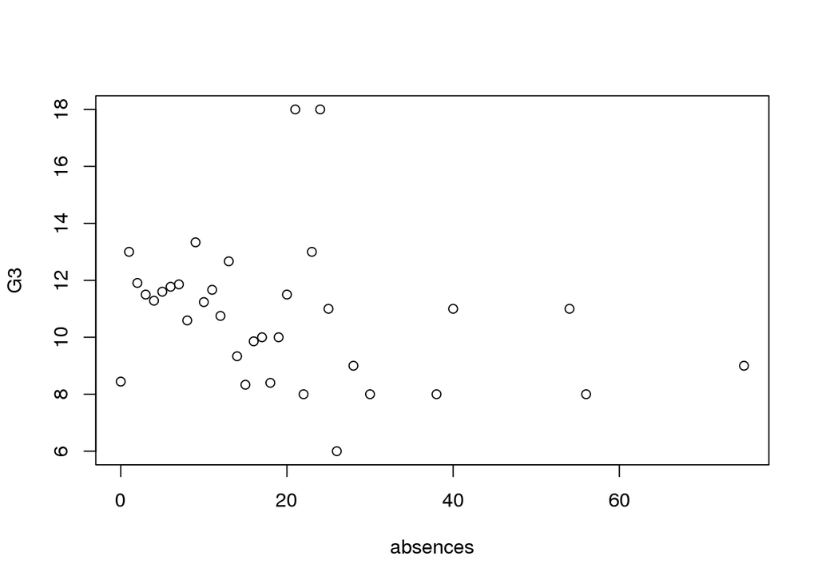

```r
plot(aggregate(studentScores$mat["G3"], studentScores$mat["absences"], mean))
```

Otra de las variables consideradas como “alta influencia” por el RandomForest es el soporte escolar (clases particulares). Sin embargo en el HeatMap no se aprecia ninguna relación. De hecho, los alumnos con clases extraescolares obtienen resultados similares al resto de alumnos

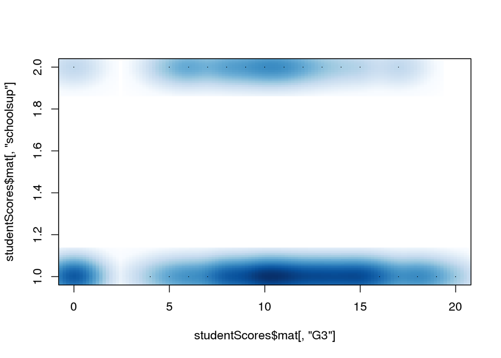

```r
smoothScatter(studentScores$mat[,"G3"], studentScores$mat[,"schoolsup"])
```

### Interpretación de los datos

En el análisis exploratorio podemos observar que hay una clara relación entre las notas finales y las horas de estudio. No obstante se puede apreciar que no es una relación lineal, que el numero óptimo de horas de estudio es de 3horas por asignatura, mas allá de eso no se produce un aumento de la calificación.

Respecto a la relación entre horas de estudio y tiempo libre, no parece haber ningún tipo de relación. La mayoría de alumnos estudian entre una y dos horas, independientemente de que tengan 2 o 4horas libres.

En cuanto al modelado del RandomForest, no parece ser efectivo en este caso particular (o no lo he modelado correctamente). Y las variables que detecta como altamente relacionadas respecto a las notas, en realidad no tienen relación.